# Análisis de datos scATAC-seq en Signac: 2700 PBMC

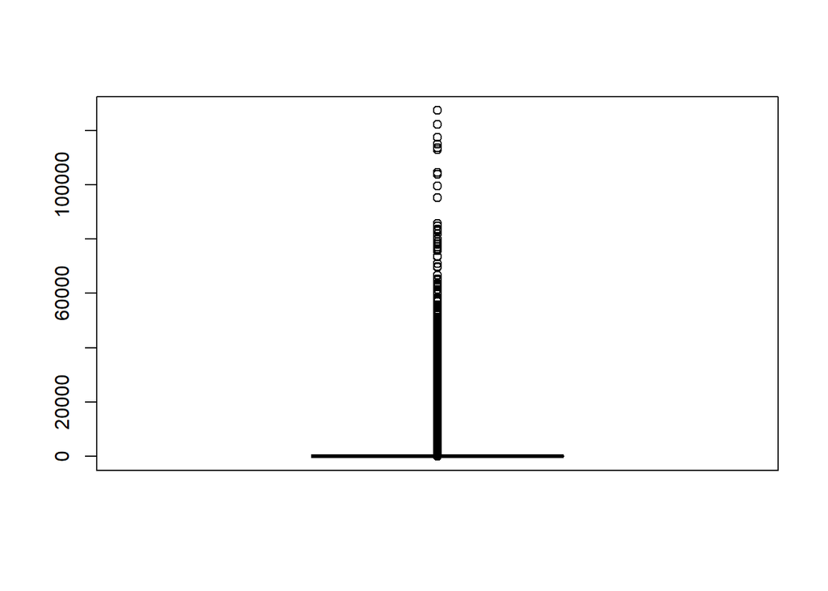

```r
boxplot(x= metadatos$peak_region_fragments)
```

```r
# OBJETO TIPO `ChromatinAssay`
ensayo_ATAC_Seq <- CreateChromatinAssay(
  counts = matriz_picos_ATAC,
  sep = c(":", "-"),
  genome = "hg19",
  fragments = "E:/Git/R/Signac PBMC/archivos_accesorios/atac_v1_pbmc_10k_fragments.tsv.gz",
  min.cells = 10,
  min.features = 200)

# OBJETO TIPO `seurat`
pbmc_Signac <- CreateSeuratObject(
  counts = ensayo_ATAC_Seq,
  assay = "peaks",
  meta.data = metadatos)

pbmc_Signac
```

```
## An object of class Seurat
## 87561 features across 8728 samples within 1 assay
## Active assay: peaks (87561 features, 0 variable features)
```

```r
pbmc_Signac[["peaks"]]
```

```
## ChromatinAssay data with 87561 features for 8728 cells
## Variable features: 0
## Genome: hg19
## Annotation present: FALSE
## Motifs present: FALSE
## Fragment files: 1
```

Los datos de la secuenciación ATAC se guardan en un objeto de tipo `ChromatinAssay`, el cual se caracteriza por presentar bolsillos para almacenar información adicional sobre motifs, anotaciones de los genes e información del genoma. A partir de dicho objeto creamos el principal objeto `seurat` donde realizaremos los análisis.

Podemos usar la función `granges()` en un objeto de tipo `seurat` que tenga como experimento activo uno de tipo `ChromatinAssay` para observar las regiones cromosómicas asociada a cada feature (gen?) del objeto. Para más información sobre la clase `ChromatinAssay`, consulte la [viñeta de interacción con objetos](https://satijalab.org/signac/articles/data_structures.html).

```r
# Exploración del ensayo/experimento de ATAC-Seq
ensayo_ATAC_Seq[1:5, 1:5]
```

```
## 5 x 5 sparse Matrix of class "dgCMatrix"
##                    AAACGAAAGAGCGAAA-1 AAACGAAAGAGTTTGA-1 AAACGAAAGCGAGCTA-1
## chr1-565107-565550                  .                  .                  .
## chr1-569174-569639                  .                  .                  .
## chr1-713460-714823                  .                  .                  2
## chr1-752422-753038                  .                  .                  .
## chr1-762106-763359                  .                  .                  4
##                    AAACGAAAGGCTTCGC-1 AAACGAAAGTGCTGAG-1
## chr1-565107-565550                  .                  .
## chr1-569174-569639                  .                  .
## chr1-713460-714823                  8                  .
## chr1-752422-753038                  .                  .
## chr1-762106-763359                  2                  .
```

```r
dim(ensayo_ATAC_Seq) # Las columnas son las células secuenciadas.. 8728 células
```

```
## [1] 87561  8728
```

```r
class(ensayo_ATAC_Seq)
```

```
## [1] "ChromatinAssay"
## attr(,"package")
## [1] "Signac"
```

```r
granges(pbmc_Signac)
```

```
## GRanges object with 87561 ranges and 0 metadata columns:
##           seqnames            ranges strand
##              <Rle>         <IRanges>  <Rle>
##       [1]     chr1     565107-565550      *
##       [2]     chr1     569174-569639      *
##       [3]     chr1     713460-714823      *
##       [4]     chr1     752422-753038      *
##       [5]     chr1     762106-763359      *
##       ...      ...               ...    ...
##   [87557]     chrY 58993392-58993760      *
##   [87558]     chrY 58994571-58994823      *
##   [87559]     chrY 58996352-58997331      *
##   [87560]     chrY 59001782-59002175      *
##   [87561]     chrY 59017143-59017246      *
##   -------
##   seqinfo: 24 sequences from an unspecified genome; no seqlengths
```

También podemos añadir al objeto `pbmc_Signac` las anotaciones del genoma humano para que ciertos comandos puedan hacer uso de dicha información.

```r
# Obtenemos las anotaciones del genoma humano hg19 desde Ensembl
annotations <- GetGRangesFromEnsDb(ensdb = EnsDb.Hsapiens.v75, verbose = F) # Este paso es lento

# Cambiamos el estilo a "UCSC" dado que los datos fueron mapeados al genoma humano "hg19"
# seqlevelsStyle(annotations) <- 'UCSC'
genome(annotations) <- "hg19"

# Añadimos las anotaciones al objeto de tipo `seurat`
Annotation(pbmc_Signac) <- annotations
Annotation(pbmc_Signac)
```

```
## GRanges object with 3072120 ranges and 5 metadata columns:
##                   seqnames        ranges strand |           tx_id   gene_name
##                      <Rle>     <IRanges>  <Rle> |     <character> <character>
##   ENSE00001489430        X 192989-193061      + | ENST00000399012      PLCXD1
##   ENSE00001536003        X 192991-193061      + | ENST00000484611      PLCXD1
##   ENSE00002160563        X 193020-193061      + | ENST00000430923      PLCXD1
##   ENSE00001750899        X 197722-197788      + | ENST00000445062      PLCXD1
##   ENSE00001489388        X 197859-198351      + | ENST00000381657      PLCXD1
##               ...      ...           ...    ... .             ...         ...
##   ENST00000361739       MT     7586-8269      + | ENST00000361739      MT-CO2
##   ENST00000361789       MT   14747-15887      + | ENST00000361789      MT-CYB
##   ENST00000361851       MT     8366-8572      + | ENST00000361851     MT-ATP8
##   ENST00000361899       MT     8527-9207      + | ENST00000361899     MT-ATP6
##   ENST00000362079       MT     9207-9990      + | ENST00000362079      MT-CO3
##                           gene_id   gene_biotype     type
##                       <character>    <character> <factor>
##   ENSE00001489430 ENSG00000182378 protein_coding     exon
##   ENSE00001536003 ENSG00000182378 protein_coding     exon
##   ENSE00002160563 ENSG00000182378 protein_coding     exon
##   ENSE00001750899 ENSG00000182378 protein_coding     exon
##   ENSE00001489388 ENSG00000182378 protein_coding     exon
##               ...             ...            ...      ...
##   ENST00000361739 ENSG00000198712 protein_coding      cds
##   ENST00000361789 ENSG00000198727 protein_coding      cds
##   ENST00000361851 ENSG00000228253 protein_coding      cds
##   ENST00000361899 ENSG00000198899 protein_coding      cds
##   ENST00000362079 ENSG00000198938 protein_coding      cds
##   -------
##   seqinfo: 25 sequences from hg19 genome
```

# 4 Métricas de calidad (QC)

Ahora podemos comenzar con el control de calidad. Los creadores de `Signac` recomiendan prestar atención a las siguientes métricas:

- **Nucleosome banding pattern**: El histograma de los tamaños de los fragmentos de ADN (de secuencias paired-end, ojo) debe exhibir un marcado patrón de bandeo de nucleosomas correspondiente a la longitud del ADN enrollado alrededor de un único nucleosoma. Esta métrica se calcula mediante la siguiente ecuación:

$$nucleosome\ signal = \frac{fragmentos\_mononucleosomales}{fragmentos\_sin\_nucleosomas}$$

- **Transcriptional start site (TSS) enrichment score**. El [proyecto ENCODE](https://www.encodeproject.org/data-standards/terms/) define el *TSS enrichment score* como el ratio de fragmentos centrados en el TSS vs fragmentos flanqueantes al TSS. Los experimentos de ATAC-Seq mal hechos suelen tener un *TSS enrichment score* bajo. Esta métrica se calcula para cada célula con el comando `TSSEnrichment()` y se almacena en los metadatos en la columna `TSS.enrichment`.
- **Número total de fragmentos (= lecturas) en picos**: Las células con muy pocas lecturas se han secuenciado con poca profundidad, mientras que las células con muchas lecturas podrían ser *doublets* (dos células secuenciadas como una), agregados de núcleos u otro tipo de artefactos. Por consiguiente se deben eliminar todas las células con valores extremos de lecturas en picos.
- **Ratio de lecturas en picos**: Representa el porcentaje de fragmentos (*i.e.* regiones cromosómicas) que caen en picos. Las células con un ratio bajo (<15~20%) suelen ser células mal secuenciadas o artefactos técnicos (ruido) y por tanto se deberían eliminar. Tenga en cuenta que el umbral de rechazo de células depende del set de picos usado.
- **Ratio de lecturas en regiones genómicas ruidosas (*blacklists*)**. El proyecto ENCODE también ha publicado para el genoma humano (hg19 y GRCh38) y otros una [lista negra](https://github.com/Boyle-Lab/Blacklist) de regiones cromosómicas que consiste en un listado de las lecturas normalmente asociadas a ruido técnico. Las células con un porcentaje elevado lecturas que mapeen a dichos loci suelen ser ruido y deben eliminarse. Las listas negras de ENCODE actualmente disponibles en `Signac` son para genoma humano(hg19 y GRCh38), ratón (mm10), Drosophila (dm3), y *C. elegans* (ce10).

Téngase en cuenta que las métricas `Total number of fragments in peaks`, `Fraction of fragments in peaks` y `Ratio reads in genomic blacklist regions` pueden obtenerse del output de `CellRanger` de 10X Genomics. También es posible analizar datasets no provenientes de 10X Genomics gracias a las utilidades que incorpora `Signac`.

```r
# DefaultAssay(pbmc_Signac) # el Assay es el correcto: "peaks"
# Calculamos el nucleosome signal score por célula
pbmc_Signac <- NucleosomeSignal(pbmc_Signac)

# Calculamos el TSS enrichment score por célula
# pbmc_Signac <- TSSEnrichment(pbmc_Signac)                                                          # PURGE ME: No funciona
# https://www.encodeproject.org/atac-seq/#standards Para interpretar los valores de TSS

# Calculamos el ratio de lecturas en picos y el ratio de lecturas que caen en
# regiones ruidosas
pbmc_Signac$pct_reads_in_peaks <- pbmc_Signac$peak_region_fragments / pbmc_Signac$passed_filters * 100
pbmc_Signac$blacklist_ratio <- pbmc_Signac$blacklist_region_fragments / pbmc_Signac$peak_region_fragments
```

We can inspect the TSS enrichment scores by grouping the cells based on the score and plotting the accessibility signal over all TSS sites. Setting the fast=TRUE option in TSSEnrichment() will only compute the TSS enrichment score without storing the entire cell by position matrix of Tn5 insertion frequency for each cell, and can save memory. However, setting fast=TRUE will not allow downstream plotting of the TSS enrichment signal for different groups of cells using the TSSPlot() function, shown here:

```r
pbmc_Signac$high.tss <- ifelse(pbmc_Signac$TSS.enrichment > 2, 'High', 'Low')
TSSPlot(pbmc_Signac, group.by = "high.tss") + NoLegend()
```

[output not shown]

```r
pbmc_Signac$nucleosome_group <- ifelse(pbmc_Signac$nucleosome_signal > 4, "NS > 4", "NS < 4")
FragmentHistogram(pbmc_Signac, group.by = "nucleosome_group")
```

[output not shown]

[figure not shown]

```r
VlnPlot(
  object = pbmc_Signac,
  features = c("pct_reads_in_peaks", "peak_region_fragments",
               "TSS.enrichment", "blacklist_ratio", "nucleosome_signal"),
  pt.size = 0.1,
  ncol = 5
)
```

```r
pbmc_Signac <- subset(
  x = pbmc_Signac,
  subset = peak_region_fragments > 3000 &
    peak_region_fragments < 20000 &
    pct_reads_in_peaks > 15 &
    blacklist_ratio < 0.05 &
    nucleosome_signal < 4 &
    TSS.enrichment > 2
)

pbmc_Signac
```

[output not shown]